# Análise Bellabeat - Google Capstone Project

Yuri Faria Frota

31/10/2021

# **Bellabeat**

Bellabeat é uma empresa de tecnologia responsável por produzir aparelhos smart especificamente para mulheres.

O background artístico de sua fundadora, Urška Sršen, proporcionou a Bellabeat a capacidade de criar belos designs para seus aparelhos, capazes de informar e inspirar mulheres de todo o mundo. Coletando dados referentes à características como, sono, atividades, estresse, e fertilidade, permitindo o empoderamento das mulheres através do conhecimento à respeito de sua saúde e hábitos diários.

Fundada em 2013, Bellabeat cresceu rapidamente e se consolidou como uma empresa de saúde da mulher baseada em tecnologias direcionadas.

Sršen sabe que uma análise dos dados pode revelar importantes insights e oportunidades de crescimento. Foi demandado ao time de análise de marketing uma análise dos dados de outros aparelhos smart (similares aos produtos da Bellabeat), e através dos insights obtidos, buscar saber mais a respeito de como as pessoas estão utilizando seus aparelhos, e como podemos direcionar essas informações para algum produto da Bellabeat.

Com as informações obtidas, ela gostaria de boas indicações de como essas tendências podem ser informativas para o departamento de marketing e estratégia.

Acesse o site para mais informações https://bellabeat.com/

## **FASE 1 - Pergunta (Ask)**

Através dos dados de equipamentos smart (como gasto calórico, tempo de atividades, dados diários referentes à qualidade do sono, entre outros), será possivel obter insights sobre como melhorar os equipamentos da Bellabeat e atender melhor as demandas de seus clientes.

Desta forma, os clientes Bellabeat terão mais conhecimento sobre seus hábitos, seu corpo, e sobre como promover uma vida saudável, proporcionando melhor qualidade de vida.

A análise desses dados pode ajudar a Bellabeat a se destacar no mercado, sendo capaz de oferecer demandas antes não ofertadas.

Teremos como objetivos principais desta análise, fornecer:

- Novos insights através de análise de dados de outros equipamentos
- Padrões e tendencias provindas dos dados
- Propostas de melhorias para os equipamentos Bellabeat
- Possibilidades de novas demandas, a partir da análise dos dados
- Informações valiosas para o departamento de estratégia e marketing

Utilizaremos a joia **Leaf**, do catálogo de produtos da Bellabeat, para nos basearmos como referência neste estudo. https://bellabeat.com/catalog/

## **FASE 2 - Preparação (Prepare)**

#### *Original (Originality)*:

Estes dados nao foram coletados originalmente pelo fabricante, e sim pela Amazon Mechanical Murk.

#### *Abrangente (Comprehensiveness)*:

Os dados não informam sexo, idade, e outras condições que poderiam gerar resultados mais precisos. Para esta análise, Não levar em conta essas características pode tornar o resutlado enviesado.

#### *Atual (Current)*:

Os dados foram coletados em 2016, e podem gerar informações desatualizadas.

#### *Citado (Cited)*:

Dados coletados pela Amazon Mechanical Murk.

Após as observações acima, podemos considerar uma escassez de informações para análises mais precisas. Desta forma, iremos obter alguns insights referentes a esta análise, e iremos tomar os resultados obtidos como um ponto inicial para próximas análises.

## Configurando o ambiente

instalando e carregando os pacotes que serao utilizados.

```r
library(readr)
library(tidyverse)
library(sqldf)
```

```r
library(ggplot2)
library(gridExtra)
```

## Importando os dados

```r
sleepDay_merged <-read_csv("C:/Users/Yuri/Documents/capstone project/fitbit_fitnesstrack_data/sleepDay_merged.csv")
weightLogInfo_merged <- read_csv("C:/Users/Yuri/Documents/capstone project/fitbit_fitnesstrack_data/weightLogInfo_merged.csv")
minuteSleep_merged <- read_csv("C:/Users/Yuri/Documents/capstone project/fitbit_fitnesstrack_data/minuteSleep_merged.csv")
minuteStepsNarrow_merged <- read_csv("C:/Users/Yuri/Documents/capstone project/fitbit_fitnesstrack_data/minuteStepsNarrow_merged.csv")
minuteIntensitiesWide_merged <- read_csv("C:/Users/Yuri/Documents/capstone project/fitbit_fitnesstrack_data/minuteIntensitiesWide_merged.csv")
minuteMETsNarrow_merged <- read_csv("C:/Users/Yuri/Documents/capstone project/fitbit_fitnesstrack_data/minuteMETsNarrow_merged.csv")
minuteCaloriesWide_merged <- read_csv("C:/Users/Yuri/Documents/capstone project/fitbit_fitnesstrack_data/minuteCaloriesWide_merged.csv")
minuteIntensitiesNarrow_merged <- read_csv("C:/Users/Yuri/Documents/capstone project/fitbit_fitnesstrack_data/minuteIntensitiesNarrow_merged.csv")
hourlyCalories_merged <- read_csv("C:/Users/Yuri/Documents/capstone project/fitbit_fitnesstrack_data/hourlyCalories_merged.csv")
hourlyIntensities_merged <- read_csv("C:/Users/Yuri/Documents/capstone project/fitbit_fitnesstrack_data/hourlyIntensities_merged.csv")
hourlySteps_merged <-read_csv("C:/Users/Yuri/Documents/capstone project/fitbit_fitnesstrack_data/hourlySteps_merged.csv")
minuteCaloriesNarrow_merged <- read_csv("C:/Users/Yuri/Documents/capstone project/fitbit_fitnesstrack_data/minuteCaloriesNarrow_merged.csv")
dailyactivity_merged <-read_csv("C:/Users/Yuri/Documents/capstone project/fitbit_fitnesstrack_data/dailyActivity_merged.csv")
dailyCalories_merged <-read_csv("C:/Users/Yuri/Documents/capstone project/fitbit_fitnesstrack_data/dailyCalories_merged.csv")
dailyIntensities_merged <-read_csv("C:/Users/Yuri/Documents/capstone project/fitbit_fitnesstrack_data/dailyIntensities_merged.csv")
dailySteps_merged <-read_csv("C:/Users/Yuri/Documents/capstone project/fitbit_fitnesstrack_data/dailySteps_merged.csv")
heartrate_seconds_merged <-read_csv("C:/Users/Yuri/Documents/capstone project/fitbit_fitnesstrack_data/heartrate_seconds_merged.csv")
```

## Checando os dados

Tomaremos como exemplo o set de atividade diária (‘dailyactivity_merged’) para demonstrar as inspeções realizadas.

```r
colnames(dailyactivity_merged)
```

```
##  [1] "Id"                       "ActivityDate"
##  [3] "TotalSteps"               "TotalDistance"
##  [5] "TrackerDistance"          "LoggedActivitiesDistance"
##  [7] "VeryActiveDistance"       "ModeratelyActiveDistance"
##  [9] "LightActiveDistance"      "SedentaryActiveDistance"
## [11] "VeryActiveMinutes"        "FairlyActiveMinutes"
## [13] "LightlyActiveMinutes"     "SedentaryMinutes"
## [15] "Calories"
```

```r
head(dailyactivity_merged)
```

```
## # A tibble: 6 x 15
##        Id ActivityDate TotalSteps TotalDistance TrackerDistance LoggedActivitie~
##     <dbl> <chr>             <dbl>         <dbl>           <dbl>            <dbl>
## 1  1.50e9 4/12/2016         13162          8.5             8.5                 0
## 2  1.50e9 4/13/2016         10735          6.97            6.97                0
## 3  1.50e9 4/14/2016         10460          6.74            6.74                0
## 4  1.50e9 4/15/2016          9762          6.28            6.28                0
## 5  1.50e9 4/16/2016         12669          8.16            8.16                0
## 6  1.50e9 4/17/2016          9705          6.48            6.48                0
## # ... with 9 more variables: VeryActiveDistance <dbl>,
## #   ModeratelyActiveDistance <dbl>, LightActiveDistance <dbl>,
## #   SedentaryActiveDistance <dbl>, VeryActiveMinutes <dbl>,
## #   FairlyActiveMinutes <dbl>, LightlyActiveMinutes <dbl>,
## #   SedentaryMinutes <dbl>, Calories <dbl>
```

```r
nrow(dailyactivity_merged)
```

```
## [1] 940
```

```r
glimpse(dailyactivity_merged)
```

```
## Rows: 940
## Columns: 15
## $ Id                       <dbl> 1503960366, 1503960366, 1503960366, 150396036~
## $ ActivityDate             <chr> "4/12/2016", "4/13/2016", "4/14/2016", "4/15/~
## $ TotalSteps               <dbl> 13162, 10735, 10460, 9762, 12669, 9705, 13019~
## $ TotalDistance            <dbl> 8.50, 6.97, 6.74, 6.28, 8.16, 6.48, 8.59, 9.8~
## $ TrackerDistance          <dbl> 8.50, 6.97, 6.74, 6.28, 8.16, 6.48, 8.59, 9.8~
## $ LoggedActivitiesDistance <dbl> 0, 0, 0, 0, 0, 0, 0, 0, 0, 0, 0, 0, 0, 0, 0, ~
## $ VeryActiveDistance       <dbl> 1.88, 1.57, 2.44, 2.14, 2.71, 3.19, 3.25, 3.5~
## $ ModeratelyActiveDistance <dbl> 0.55, 0.69, 0.40, 1.26, 0.41, 0.78, 0.64, 1.3~
## $ LightActiveDistance      <dbl> 6.06, 4.71, 3.91, 2.83, 5.04, 2.51, 4.71, 5.0~
## $ SedentaryActiveDistance  <dbl> 0, 0, 0, 0, 0, 0, 0, 0, 0, 0, 0, 0, 0, 0, 0, ~
## $ VeryActiveMinutes        <dbl> 25, 21, 30, 29, 36, 38, 42, 50, 28, 19, 66, 4~
## $ FairlyActiveMinutes      <dbl> 13, 19, 11, 34, 10, 20, 16, 31, 12, 8, 27, 21~
## $ LightlyActiveMinutes     <dbl> 328, 217, 181, 209, 221, 164, 233, 264, 205, ~
## $ SedentaryMinutes         <dbl> 728, 776, 1218, 726, 773, 539, 1149, 775, 818~
## $ Calories                 <dbl> 1985, 1797, 1776, 1745, 1863, 1728, 1921, 203~
```

**Utilizando as mesmas funções descritas acima para todos sets de dados abaixo.**

*Dias de sono (sleepDay_merged)*

*Intensidade diária (dailyIntensities_merged)*

*Calorias diárias (dailyCalories_merged)*

*Registro de peso (weightLogInfo_merged)*

*Passos diários (dailySteps_merged)*

## Verificando a integridade dos dados

**Vamos verificar quantas pessoas analisadas estão presentes em casa set de dados, separando apenas a quantidade de Ids distintos, e contando as linhas resultantes.**

```r
teste1 <- sqldf ('SELECT DISTINCT Id FROM "dailyCalories_merged"')
nrow(teste1)
```

```
## [1] 33
```

```r
teste2 <- sqldf ('SELECT DISTINCT Id FROM "dailyactivity_merged"')
nrow(teste2)
```

```
## [1] 33
```

```r
teste3 <- sqldf ('SELECT DISTINCT Id FROM "dailyIntensities_merged"')
nrow(teste3)
```

```
## [1] 33
```

```r
teste4 <- sqldf ('SELECT DISTINCT Id FROM "dailySteps_merged"')
nrow(teste4)
```

```
## [1] 33
```

```r
teste5 <- sqldf ('SELECT DISTINCT Id FROM "sleepDay_merged"')
nrow(teste5)
```

```
## [1] 24
```

```r
teste6 <- sqldf ('SELECT DISTINCT Id FROM "weightLogInfo_merged"')
nrow(teste6)
```

```
## [1] 8
```

**Verificando a quantidade de dias registrados.**

```r
n_distinct(dailyactivity_merged$ActivityDate)
```

```
## [1] 31
```

**Durante a checagem, observou-se que ambos os sets abaixo possuem uma quantidade de registros inferior aos registros dos outros sets analisados.**

*Registro de peso (weightLogInfo_merged)*

```r
nrow(weightLogInfo_merged)
```

```
## [1] 67
```

```r
n_distinct(weightLogInfo_merged$Id)
```

```
## [1] 8
```

```r
nrow(sleepDay_merged)
```

```
## [1] 413
```

```r
n_distinct(sleepDay_merged$Id)
```

```
## [1] 24
```

**Ambos sets acima se apresentam incompletos, onde nao constam todos os participantes, e com menos registros que os demais, portanto nao vamos considerá-los em nossa análise.**

**Vamos proceder com a utilização das tabelas com dados diários, e verificar se as colunas iguais possuem os mesmos dados entre as tabelas.** **Para isso utilizamos as seguintes funções:**

**‘dailyActivity_merged’ ∩ ‘dailyCalories_merged’**

```r
daily_activity1 <- dailyactivity_merged %>% select(Id, ActivityDate, Calories)
check1 <- sqldf ('SELECT * FROM daily_activity1 INTERSECT SELECT * FROM dailyCalories_merged')
nrow(check1)
```

```
## [1] 940
```

```r
n_distinct(check1$Id)
```

```
## [1] 33
```

**‘dailyActivity_merged’ ∩ ‘dailyIntensities_merged’**

```r
daily_activity2 <- dailyactivity_merged %>% select(Id, ActivityDate, SedentaryMinutes, LightlyActiveMinutes, FairlyActiveMinutes, VeryActiveMinutes, SedentaryActiveDistance, LightActiveDistance, ModeratelyActiveDistance, VeryActiveDistance)
check2 <- sqldf('SELECT * FROM daily_activity2 INTERSECT SELECT * FROM dailyIntensities_merged')
nrow(check2)
```

```
## [1] 940
```

```r
n_distinct(check2$Id)
```

```
## [1] 33
```

**‘dailyActivity_merged’ ∩ ‘dailySteps_merged’**

```r
daily_activity3 <- dailyactivity_merged %>%  select(Id, ActivityDate, TotalSteps)
check3 <- sqldf('SELECT * FROM daily_activity3 INTERSECT SELECT * FROM dailySteps_merged')
nrow(check3)
```

```
## [1] 940
```

```r
n_distinct(check3$Id)
```

```
## [1] 33
```

**as 940 linhas encontradas em suas intersecções (check1, check2, e check3) afirmam que as colunas entre as tabelas possuem os mesmos dados, portanto podemos nos basear na tabela ‘dailyActivity_merged’ como um resumo geral de todos os dados diários coletados.**

## **Fase 3 e 4: Processamento e análise dos dados (Process and Analyze)**

**Vamos agora gerar um resumo das caracteristicas gerais dos hábitos diários para iniciar nossa análise.**

```r
dailyactivity_merged %>%  summary()
```

```
##        Id            ActivityDate         TotalSteps    TotalDistance
##  Min.   :1.504e+09   Length:940         Min.   :    0   Min.   : 0.000
##  1st Qu.:2.320e+09   Class :character   1st Qu.: 3790   1st Qu.: 2.620
##  Median :4.445e+09   Mode  :character   Median : 7406   Median : 5.245
##  Mean   :4.855e+09                      Mean   : 7638   Mean   : 5.490
##  3rd Qu.:6.962e+09                      3rd Qu.:10727   3rd Qu.: 7.713
##  Max.   :8.878e+09                      Max.   :36019   Max.   :28.030
##  TrackerDistance  LoggedActivitiesDistance VeryActiveDistance
##  Min.   : 0.000   Min.   :0.0000           Min.   : 0.000
##  1st Qu.: 2.620   1st Qu.:0.0000           1st Qu.: 0.000
##  Median : 5.245   Median :0.0000           Median : 0.210
##  Mean   : 5.475   Mean   :0.1082           Mean   : 1.503
##  3rd Qu.: 7.710   3rd Qu.:0.0000           3rd Qu.: 2.053
##  Max.   :28.030   Max.   :4.9421           Max.   :21.920
##  ModeratelyActiveDistance LightActiveDistance SedentaryActiveDistance
##  Min.   :0.0000           Min.   : 0.000      Min.   :0.000000
##  1st Qu.:0.0000           1st Qu.: 1.945      1st Qu.:0.000000
##  Median :0.2400           Median : 3.365      Median :0.000000
##  Mean   :0.5675           Mean   : 3.341      Mean   :0.001606
##  3rd Qu.:0.8000           3rd Qu.: 4.782      3rd Qu.:0.000000
##  Max.   :6.4800           Max.   :10.710      Max.   :0.110000
##  VeryActiveMinutes FairlyActiveMinutes LightlyActiveMinutes SedentaryMinutes
##  Min.   :  0.00    Min.   :  0.00      Min.   :  0.0        Min.   :   0.0
##  1st Qu.:  0.00    1st Qu.:  0.00      1st Qu.:127.0        1st Qu.: 729.8
##  Median :  4.00    Median :  6.00      Median :199.0        Median :1057.5
##  Mean   : 21.16    Mean   : 13.56      Mean   :192.8        Mean   : 991.2
##  3rd Qu.: 32.00    3rd Qu.: 19.00      3rd Qu.:264.0        3rd Qu.:1229.5
##  Max.   :210.00    Max.   :143.00      Max.   :518.0        Max.   :1440.0
##     Calories
##  Min.   :   0
##  1st Qu.:1828
##  Median :2134
##  Mean   :2304
##  3rd Qu.:2793
##  Max.   :4900
```

```r
sleepDay_merged %>%  summary ()
```

```
##        Id              SleepDay         TotalSleepRecords TotalMinutesAsleep
##  Min.   :1.504e+09   Length:413         Min.   :1.000     Min.   : 58.0
##  1st Qu.:3.977e+09   Class :character   1st Qu.:1.000     1st Qu.:361.0
##  Median :4.703e+09   Mode  :character   Median :1.000     Median :433.0
##  Mean   :5.001e+09                      Mean   :1.119     Mean   :419.5
##  3rd Qu.:6.962e+09                      3rd Qu.:1.000     3rd Qu.:490.0
##  Max.   :8.792e+09                      Max.   :3.000     Max.   :796.0
##  TotalTimeInBed
##  Min.   : 61.0
##  1st Qu.:403.0
##  Median :463.0
##  Mean   :458.6
##  3rd Qu.:526.0
##  Max.   :961.0
```

**Através do resumo, podemos obter a média diária de alguns dados:**

- Passos dados : 7638
- Distância percorrida : 5.490m / 5.49 km
- Perda calórica :2304 kcal
- Minutos Sedentários : 991.2 / 16.52 horas
- Minutos ativos : 227.52 / 3.8 horas
- Minutos de sono : 419.5 / 7 horas

**Nesta breve análise já podemos deduzir algumas características dos participantes:**

- Em média, são sedentários (mais de 16 horas por dia com atividades sedentárias).
- Dormem pouco (menos do que as 8 horas habituais).

**Vamos observar alguns gráficos para obter alguns insights significativos.**

```r
daily_activity4 <- sqldf ('SELECT Id, ActivityDate,Calories, TotalSteps, TotalDistance, TrackerDistance, LoggedActivitiesDistance, (VeryActiveDistance+ModeratelyActiveDistance+LightActiveDistance) AS ActiveDistanceTotal,SedentaryActiveDistance, (VeryActiveMinutes+FairlyActiveMinutes+LightlyActiveMinutes) AS ActiveMinutesTotal, SedentaryMinutes FROM "dailyactivity_merged"')

colnames(daily_activity4)
```

```
##  [1] "Id"                       "ActivityDate"
##  [3] "Calories"                 "TotalSteps"
##  [5] "TotalDistance"            "TrackerDistance"
##  [7] "LoggedActivitiesDistance" "ActiveDistanceTotal"
##  [9] "SedentaryActiveDistance"  "ActiveMinutesTotal"
## [11] "SedentaryMinutes"
```

```r
nrow(daily_activity4)
```

```
## [1] 940
```

```r
distanciamaximaplot<- ggplot(data=dailyactivity_merged) +
  geom_point(mapping=aes(x=TotalDistance, y= Calories, color = 'Orange'))+
  labs (title = "DISTÂNCIA TOTAL", subtitle = "em km ",
        x = "Distância Total (km)", y = "Perda Calórica")+
  theme(legend.position = "none") +
  geom_smooth(method=lm,mapping = aes (x=TotalDistance, y= Calories ))


tempoleveplot <- ggplot(data=dailyactivity_merged) +
  geom_point(mapping=aes(x=LightlyActiveMinutes, y= Calories, color = 'Orange'))+
  labs (title = "ATIVIDADE LEVE", subtitle = "em min ", x = "Atividade leve (min)", y = "Perda Calórica") +
  theme(legend.position = "none") +
  geom_smooth(method=lm, mapping = aes (x=LightlyActiveMinutes, y= Calories ))


tempointensoplot <-ggplot(data=dailyactivity_merged) +
  geom_point(mapping=aes(x=VeryActiveMinutes, y= Calories, color = 'Orange'))+
  labs (title = "ATIVIDADE INTENSA", subtitle = "em min ", x = "atividade intensa (min)", y = "Perda Calórica") +
  theme(legend.position = "none") +
  geom_smooth(method=lm,mapping = aes (x=VeryActiveMinutes, y= Calories ))


tempoesedentarioplot<-ggplot(data=dailyactivity_merged) +
  geom_point(mapping=aes(x=SedentaryMinutes, y= Calories, color = 'Orange'))+
  labs (title = "ATIVIDADE SEDENTARIA", subtitle = "em min ", x = "Atividade sedentária (min)", y = "Perda Calórica") +
  theme(legend.position = "none") +
  geom_smooth(method=lm, mapping = aes (x=SedentaryMinutes, y= Calories ))

tempototalplot<-ggplot(data=daily_activity4) +
  geom_point(mapping=aes(x=ActiveMinutesTotal, y= Calories, color = 'Orange'))+
  labs (title = "ATIVIDADE TOTAL", subtitle = "em min ",
        caption= "Criado por Yuri Faria Frota", x = "Atividade total (min)", y = "Perda Calórica") +
  theme(legend.position = "none") +
  geom_smooth(method=lm, mapping = aes (x=ActiveMinutesTotal, y= Calories ))
```

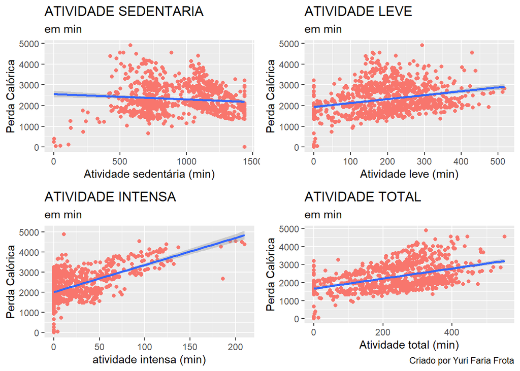

```r
grid.arrange(tempoesedentarioplot, tempoleveplot, tempointensoplot, tempototalplot, nrow = 2)
```

**Note a diferença da perda calórica de acordo com o tipo de atividade. É evidente a importancia de manter atividades, leves, moderadas, ou intensas, para e obter um consumo calórico eficiente.**

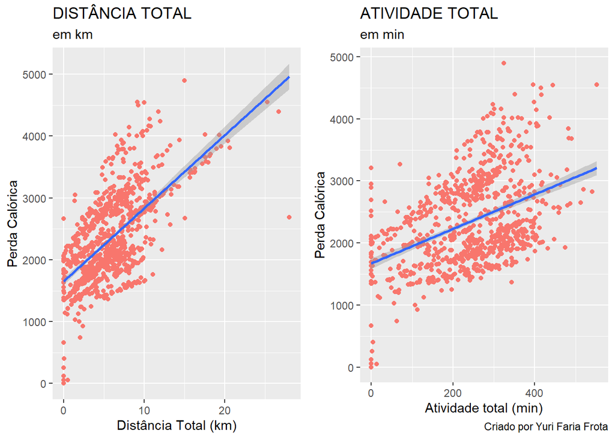

```r
grid.arrange(distanciamaximaplot, tempototalplot, nrow = 1)
```

**Longas caminhadas, sob atividades leves ou moderadas, também são eficientes para perder calorias.**

```r
sedentario <- ggplot(data=dailyactivity_merged) + geom_point(mapping = aes (x=TotalSteps, y=Calories, color = SedentaryMinutes))

leve <- ggplot(data=dailyactivity_merged) + geom_point(mapping = aes (x=TotalSteps, y=Calories, color = LightlyActiveMinutes))

moderado <- ggplot(data=dailyactivity_merged) + geom_point(mapping = aes (x=TotalSteps, y=Calories, color = FairlyActiveMinutes))

intenso <- ggplot(data=dailyactivity_merged) + geom_point(mapping = aes (x=TotalSteps, y=Calories, color = VeryActiveMinutes))
```

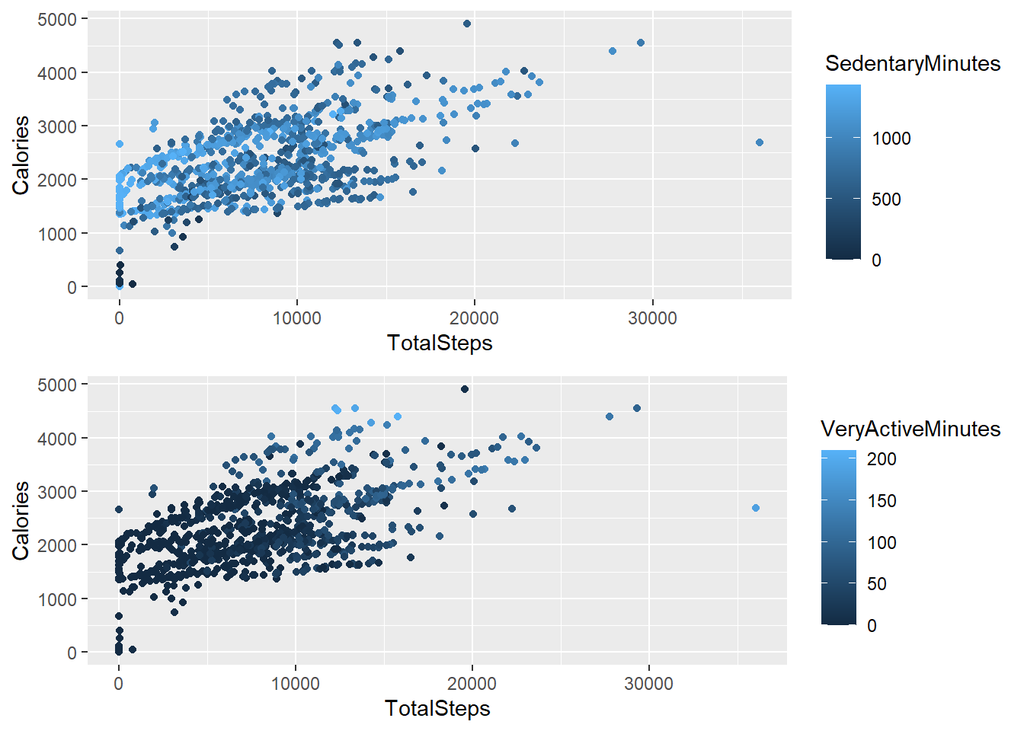

```r
grid.arrange(sedentario, intenso, nrow = 2)
```

**O maior tempo de atividades dos usuários é de forma sedentária. Perceba que minutos de atividade elevada contribuem significativamente no consumo calórico.**

```r
semanasono <- sqldf ('SELECT Id, SleepDay , TotalMinutesAsleep, CASE WHEN
       SleepDay = "4/18/2016 12:00:00 AM" OR SleepDay = "4/25/2016 12:00:00 AM" OR SleepDay = "5/2/2016 12:00:00 AM" OR SleepDay = "5/9/2016 12:00:00 AM" THEN "2-segunda"
       WHEN SleepDay = "4/12/2016 12:00:00 AM" OR SleepDay = "4/19/2016 12:00:00 AM" OR SleepDay = "4/26/2016 12:00:00 AM" OR SleepDay = "5/3/2016 12:00:00 AM" OR SleepDay = "5/10/2016 12:00:00 AM" THEN "3-terca"
       WHEN SleepDay = "4/13/2016 12:00:00 AM" OR SleepDay = "4/20/2016 12:00:00 AM" OR SleepDay = "4/27/2016 12:00:00 AM" OR SleepDay = "5/4/2016 12:00:00 AM" OR SleepDay = "5/11/2016 12:00:00 AM" THEN "4-quarta"
       WHEN SleepDay = "4/14/2016 12:00:00 AM" OR SleepDay = "4/21/2016 12:00:00 AM" OR SleepDay = "4/28/2016 12:00:00 AM" OR SleepDay = "5/5/2016 12:00:00 AM" OR SleepDay = "5/12/2016 12:00:00 AM" THEN "5-quinta"
       WHEN SleepDay = "4/15/2016 12:00:00 AM" OR SleepDay = "4/22/2016 12:00:00 AM" OR SleepDay = "4/29/2016 12:00:00 AM" OR SleepDay = "5/6/2016 12:00:00 AM" THEN "6-sexta"
       WHEN SleepDay = "4/16/2016 12:00:00 AM" OR SleepDay = "4/23/2016 12:00:00 AM" OR SleepDay = "4/30/2016 12:00:00 AM" OR SleepDay = "5/7/2016 12:00:00 AM" THEN "7-sabado"
       WHEN SleepDay = "4/17/2016 12:00:00 AM" OR SleepDay = "4/24/2016 12:00:00 AM" OR SleepDay = "5/1/2016 12:00:00 AM" OR SleepDay = "5/8/2016 12:00:00 AM" THEN "1-domingo"
       ELSE 0 end as diadasemana FROM "sleepDay_merged" ')
```

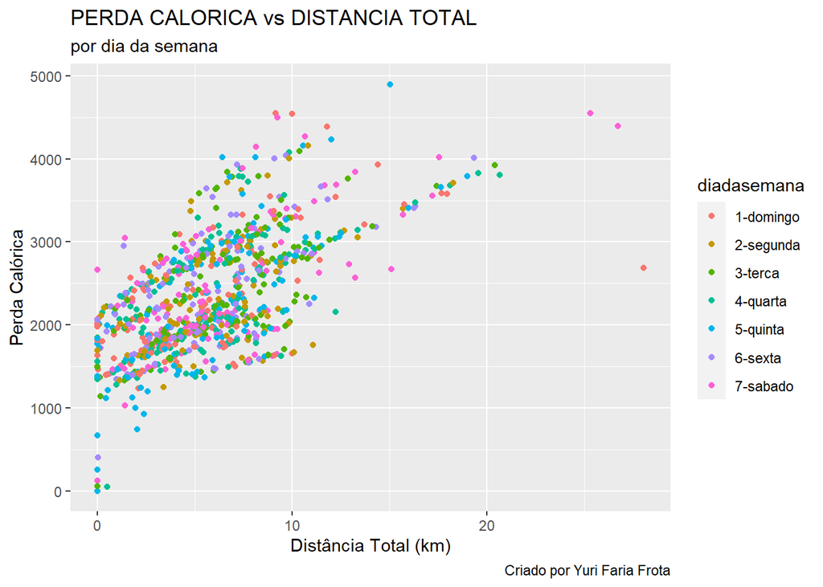

```r
ggplot(data=semana1) +
  geom_point(mapping=aes(x=TotalDistance, y= Calories, color = diadasemana ))+
  labs (title = "PERDA CALORICA vs DISTANCIA TOTAL ", subtitle = "por dia da semana",
        caption= "Criado por Yuri Faria Frota", x = "Distância Total (km)", y = "Perda Calórica")
```

[output not shown]

**Numa distribuição pelos dias da semana, podemos observar que não há nenhuma discrepância observável. Ou seja, os usuários não possuem habitos diferentes durante dias de semana ou finais de semana.**

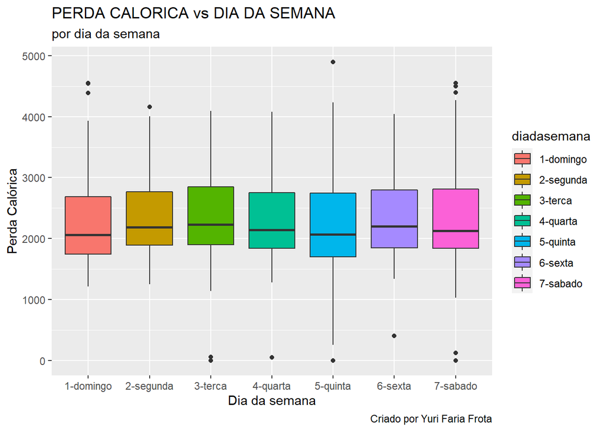

```r
ggplot(data=semana1) +
  geom_boxplot(mapping=aes(x=diadasemana, y= Calories, fill = diadasemana ))+
  labs (title = "PERDA CALORICA vs DIA DA SEMANA ", subtitle = "por dia da semana",
        caption= "Criado por Yuri Faria Frota", x = "Dia da semana", y = "Perda Calórica")
```

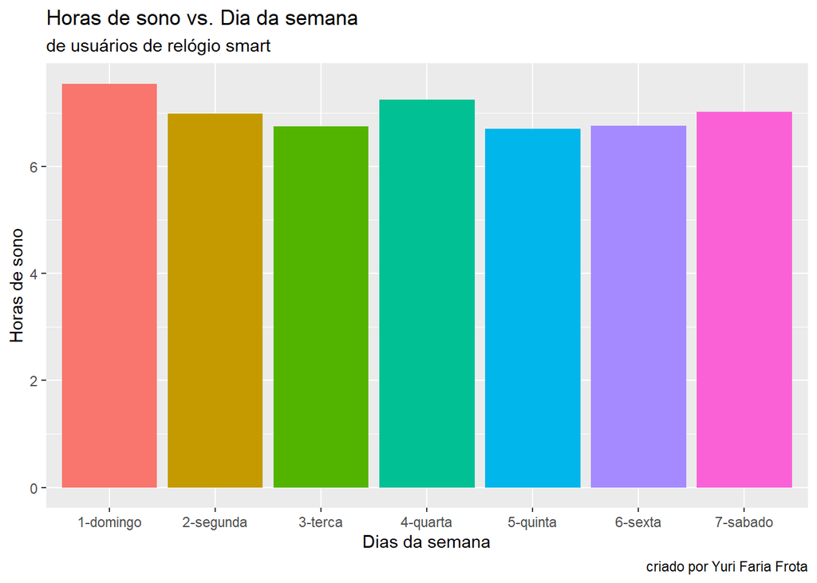

```r
semanasono %>%
  group_by(diadasemana) %>%
  summarise(totalsono = mean(TotalMinutesAsleep)) %>%
  ggplot(aes(x = diadasemana, y = totalsono/60, fill = diadasemana)) +
  geom_col() +
  labs (title = "Horas de sono vs. Dia da semana", subtitle = "de usuários de relógio smart ",
        caption= "criado por Yuri Faria Frota", x = "Dias da semana", y = "Horas de sono") + theme(legend.position = "none")
```

**Podemos notar um ligeiro acrescimo nas horas de sono aos domingos, e às quartas-feiras.**

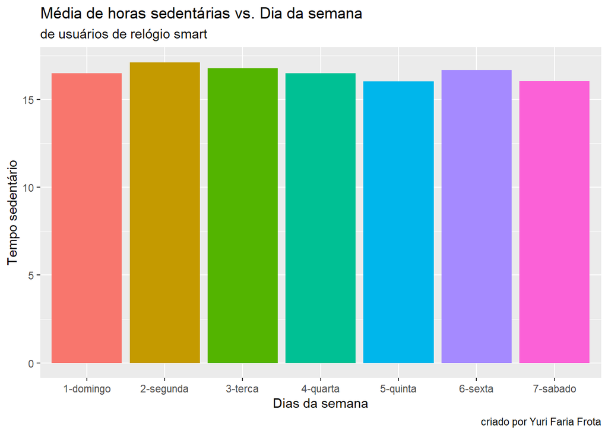

```r
semana1 %>%
  group_by(diadasemana) %>%
  summarise( meansedentaryminutes= mean(SedentaryMinutes) ) %>%
  ggplot(aes(x = diadasemana, y = (meansedentaryminutes/60), fill = diadasemana)) +
  geom_col() +
  labs (title = "Média de horas sedentárias vs. Dia da semana", subtitle = "de usuários de relógio smart",
        caption= "criado por Yuri Faria Frota", x = "Dias da semana", y = "Tempo sedentário") + theme(legend.position = "none")
```

**O gráfico acima representa uma média de horas sedentárias, por dia da semana. Note que a diferença é bem pequena, mostrando que de uma forma geral, as pessoas se mantem em atividade sedentária durante todos os dias, inclusive nos finais de semanas.**

## **Fase 5 - Compartilhar (Share)**

As análises acima nos levam as seguintes conclusões:

Em média, os usuários desses equipamentos smart são sedentários (média maior que 16 horas por dia com atividades sedentárias) e dormem pouco (menos do que as 8 horas habituais). Isso ja nos leva a um perfil dos usuários: **Pessoas que precisam melhorar sua qualidade de vida.**

Através dos gráficos vimos a importância de se manter ativo, tambêm com atividades mais intensas, gerando acrescimos significativos na perda calórica.

Vimos tambem que o simples fato de caminhar (atividade leve), já é o suficiente para manter uma boa taxa de atividade, gerando tambem impactos significativos no consumo de calorias. O importante é se exercitar.

Sugestões

- Queremos melhorar a qualidade de vida de nossos usuários. Enfatizar as características mais importantes, e mostrar a evolução para o usuário atraves de um feedback dos dados, pode fazê-lo se comprometer mais com sua qualidade de vida, e consequentemente com os produtos e serviços da Belabbeat.
- Criação de um banco de dados dos equipamentos da Belabbeat, para direcionar os insights de uma forma mais eficiente.
- O gasto calórico praticamente não varia de acordo com os dias da semana, poderiamos colocar alguma forma de incentivar a realização de atividades através de ‘metas’ a serem cumpridas? algum tipo de “gameficação”?
- Dados como peso e características do sono podem gerar importantes informações. É importante a criação de maneiras mais eficazes de se obter esses dados, e pesquisar mais afundo os reais motivos por trás da dificuldade de obtê-los.